# Abacavirinol

## Inferential Results

```
## Pearson's Chi-squared test with Yates' continuity correction
##
## Observed Counts:
##         treatment
## infected drug placebo
##     aids   20       9
##     none  287     285
##
## Counts Expected by Null:
##         treatment
## infected   drug placebo
##     aids  14.81   14.19
##     none 292.19  279.81
##
## Contributions to the chi-square statistic:
##         treatment
## infected drug placebo
##     aids 1.82    1.90
##     none 0.09    0.10
##
##
## Chi-Square Statistic = 3.1843
## Degrees of Freedom of the table = 1
## P-Value = 0.0743
```

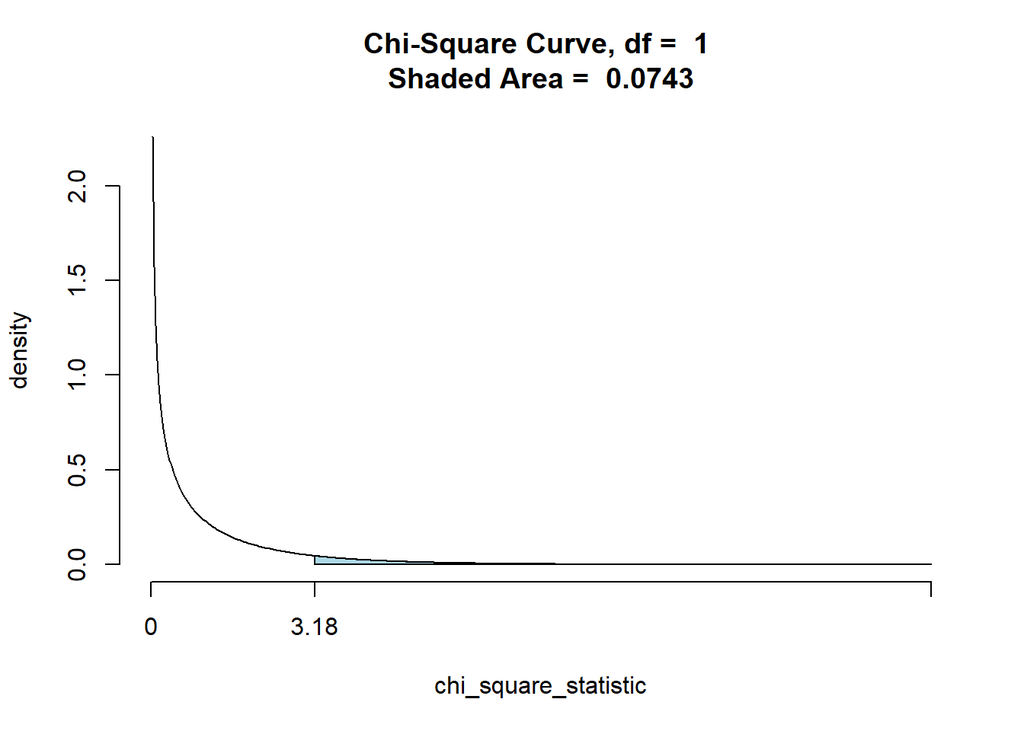

```r
chisqtestGC(resultsLGBT, graph = TRUE)
```

```r
fisher.test(resultsLGBT)
```

```
##
##  Fisher's Exact Test for Count Data
##
## data:  resultsLGBT
## p-value = 0.05698
## alternative hypothesis: true odds ratio is not equal to 1
## 95 percent confidence interval:
##  0.9400645 5.5951059
## sample estimates:
## odds ratio
##   2.203969
```

According to the chi-squared test it shows that 20 people who took the drug ended up with aids while 287 did not have aids. Then 9 people who took the placebo ended up with aids while 285 did not. The chi-squared test also gave us a p-value of 0.0743 which is not enough to reject the null hypothesis. Although, we want to make sure of the p-value so that’s where the fisher test come in and gives us a p-value of 0.05698 which means we can’t reject the null hypothesis.

# Discussion and Conclusion

Now this is another case where the drug does not seem to be work. looking at the bar graph it seems that the drug does not work. Although, we need to take a closer look at the data to make sure what we are seeing is really true. According to the statistical data shows that 68.97% of people with aids took the drug while 31.03%% of people took the placebo. Now that’s roughly about 37% difference. Let’s dig a little bit deeper 20 out of 307 people who took the drug ended up with aids. While 9 out of 294 people who took the placebo ended up with aids. Lets keep going according to the Chi-squared test we have a p-value of 0.074 and the fisher test gives off a p-value of 0.0569. Both of the p-vaules is over our .05 vaule. This means we can’t reject the null hypothesis. Which means the drug does not work.This just goes to show you, something that works for the whole may not work for everyone.